# OSA Clinical Trials

Author

Tyler Gallagher

# Introduction:

Obstructive sleep apnea (OSA) is a highly prevalent condition in the United States that significantly affects the health and quality of life of many individuals. While the gold standard treatment for OSA has historically been continuous positive airway pressure (cPAP) devices, such devices are uncomfortable and often subject to reported poor compliance. Thus, many clinical trials are underway studying alternatives to cPAP. However, the efficacy of various treatment is likely to vary depending on the cohort studied.

Therefore, we are interested in exploring the landscape of clinical trials for the treatment of OSA in the United States. The specific questions that we hope to answer include: 1) How have the number of new clinical trials in the United States changed over time? 2) What are the characteristics of the populations studied by these clinical trials? 3) What is being studied in these clinical trials, and by whom?

# Methods:

ClinicalTrials.gov was utilized to collect data on clinical trials for OSA treatment. To find clinical trials, the search term “Obstructive Sleep Apnea” was queried with filters “Not yet recruiting,” “Recruiting,” “Active, not recruiting” and “Completed” selected in the United States for studies beginning between January 1, 2013 and December 31, 2022. All data criteria available were selected for download. Before statistical analysis, additional screening was completed to ensure included studies were only randomized control trials for treatment of OSA. Descriptive statistical analysis was completed in R.

# Preliminary Analysis and Results:

Initial Data preparation:

```r
library(readxl)
```

```r
file_path <- "/Users/TylerGallagher13/Desktop/Research/Jara Projects/OSA Clinical Trials/ctg-studies-01-Del.xlsx"
osaclintrial <- read_excel(file_path)
head(osaclintrial)
```

```
# A tibble: 6 × 48
  NCT_Number  Study_Title                URL   Acronym Study_Status Study_Design
  <chr>       <chr>                      <chr> <chr>   <chr>        <chr>
1 NCT04876625 OA Therapy for Mouth-brea… http… OATMB   COMPLETED    Allocation:…
2 NCT02180672 Steroids for Pediatric Ap… http… SPARK   COMPLETED    Allocation:…
3 NCT05071612 Parallel Arm Trial of AD1… http… MARIPO… COMPLETED    Allocation:…
4 NCT02484300 The Effect of Melatonin o… http… <NA>    COMPLETED    Allocation:…
5 NCT03243487 ThErapy Adherence Managem… http… <NA>    COMPLETED    Allocation:…
6 NCT03858751 Pharmacological Activatio… http… <NA>    RECRUITING   Allocation:…
# ℹ 42 more variables: Intervention_Type <chr>, Inclusion <chr>,
#   Brief_Summary <chr>, Study_Type <chr>, Interventions <chr>, Results <chr>,
#   Conditions <chr>, Primary_Outcome_Measures <chr>,
#   Secondary_Outcome_Measures <chr>, Other_Outcome_Measures <chr>,
#   Sponsor <chr>, Sponsor_Type <chr>, Collaborators <chr>, Sex <chr>,
#   Age <chr>, Phases <chr>, Enrollment <dbl>, `Funder Type` <chr>,
#   `Study Type` <chr>, `Study Design` <chr>, `Other IDs` <chr>, …
```

```r
library(dplyr)
library(stringr)
osaclintrial <- osaclintrial %>%
  mutate(Start_Year = as.integer(str_extract(`Start Date`, "\\d{4}")))
```

```r
summary(osaclintrial$Start_Year)
```

```
   Min. 1st Qu.  Median    Mean 3rd Qu.    Max.
   2013    2015    2017    2018    2020    2022
```

## EDA

Exploratory data analysis demonstrated 119 observations and 48 variables (columns). Further analysis revealed no missing or unexpected values for any of the variables of interest.

## Question 1: How have the number of new clinical trials in the United States changed over time?

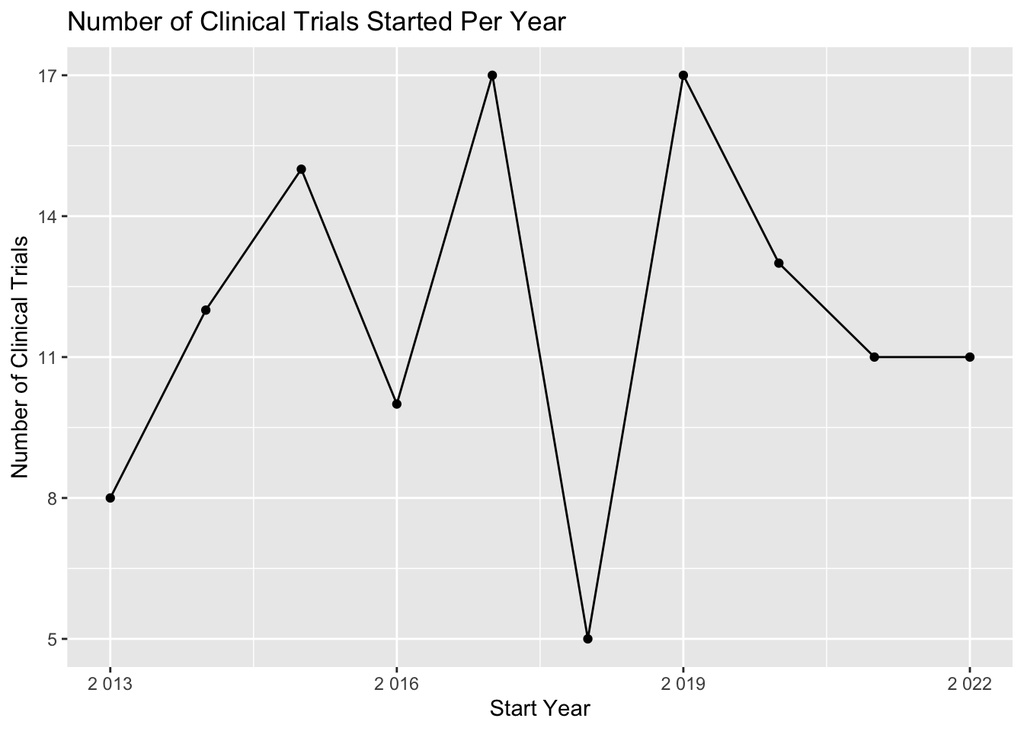

```r
library(ggplot2)
summary_table <- osaclintrial %>%
  group_by(Start_Year) %>%
  summarise(Count = n())
ggplot(summary_table, aes(x = Start_Year, y = Count)) +
  geom_line() +
  geom_point() +
  labs(
    title = "Number of Clinical Trials Started Per Year",
    x = "Start Year",
    y = "Number of Clinical Trials"
  ) +
  scale_x_continuous(breaks = seq(min(summary_table$Start_Year), max(summary_table$Start_Year), by = 3), labels = scales::number_format(scale = 1)) +
  scale_y_continuous(breaks = seq(min(summary_table$Count), max(summary_table$Count), by = 3), labels = scales::number_format(scale = 1))
```

```r
start_year_counts <- table(osaclintrial$Start_Year)
start_year_counts_df <- as.data.frame(start_year_counts)
colnames(start_year_counts_df) <- c("Start_Year", "Count")
summary_stats <- summary(start_year_counts_df$Count)
print(summary_stats)
```

```
   Min. 1st Qu.  Median    Mean 3rd Qu.    Max.
   5.00   10.25   11.50   11.90   14.50   17.00
```

Number of randomized control trials started for the treatment of OSA has varied form 5 to 17 per year over the past 10 years (2013-2022). On average, about 12 new clinical trials were started annually. While the data has been variable on number per year, there is no clear increase or decrease of numbers of clinical trials started for treatment of OSA annually in the US.

## Question 2: What are the characteristics of the populations studied by these clinical trials?

```r
table(osaclintrial$Age)
```

```
             ADULT ADULT, OLDER_ADULT              CHILD       CHILD, ADULT
                 4                108                  5                  2
```

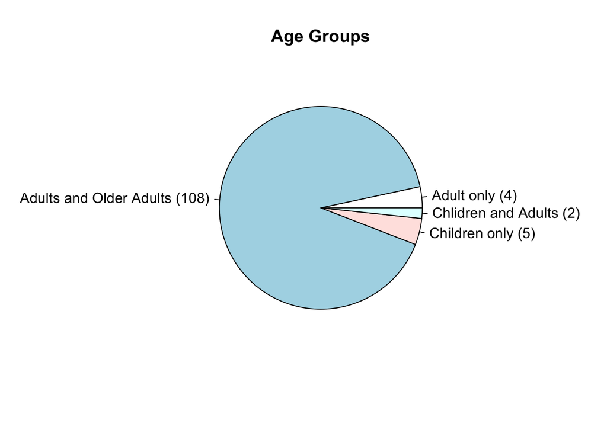

```r
age_groups <- c(
  "Adult only" = 4,
  "Adults and Older Adults" = 108,
  "Children only" = 5,
  "Chlidren and Adults" = 2
)
pie(age_groups, labels = paste(names(age_groups), " (", age_groups, ")", sep = ""), main = "Age Groups")
```

```r
table(osaclintrial$Sex)
```

```
   ALL FEMALE   MALE
   117      1      1
```

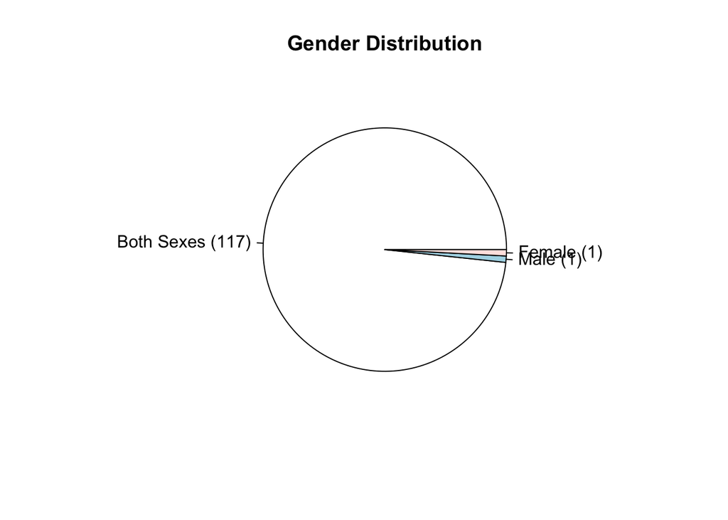

```r
gender_summary <- c(
  "Both Sexes" = 117,
  "Male" = 1,
  "Female" = 1
)
pie(gender_summary, labels = paste(names(gender_summary), " (", gender_summary, ")", sep = ""), main = "Gender Distribution")
```

```r
summary(osaclintrial$Enrollment)
```

```
   Min. 1st Qu.  Median    Mean 3rd Qu.    Max.
    6.0    25.5    60.0   129.9   131.5  1873.0
```

Overall, it appears that most clinical trials (95.8%) are studying adults with OSA, while only 5.9% study pediatric OSA. Almost all clinical trials study both males and females, though one studies exclusively males or females, respectively. The average enrollment goal in each clinical trial is about 130, with the n ranging from 6 to 1,873.

## Question 3: What treatments are being studied in these clinical trials, and by whom?

```r
code_to_label <- c("2" = "Medication",
                   "4" = "Nerve Simulation device",
                   "5" = "Other physical appliance",
                   "6" = "PAP variant",
                   "7" = "Other",
                   "8" = "Physical therapy",
                   "9" = "Behavioral intervention/Therapy")
osaclintrial$Intervention_Type <- factor(osaclintrial$Intervention_Type, levels = names(code_to_label), labels = code_to_label)
intervention_frequencies <- table(osaclintrial$Intervention_Type)
print(intervention_frequencies)
```

```
                     Medication         Nerve Simulation device
                             47                               2
       Other physical appliance                     PAP variant
                             11                              22
                          Other                Physical therapy
                              7                               6
Behavioral intervention/Therapy
                             23
```

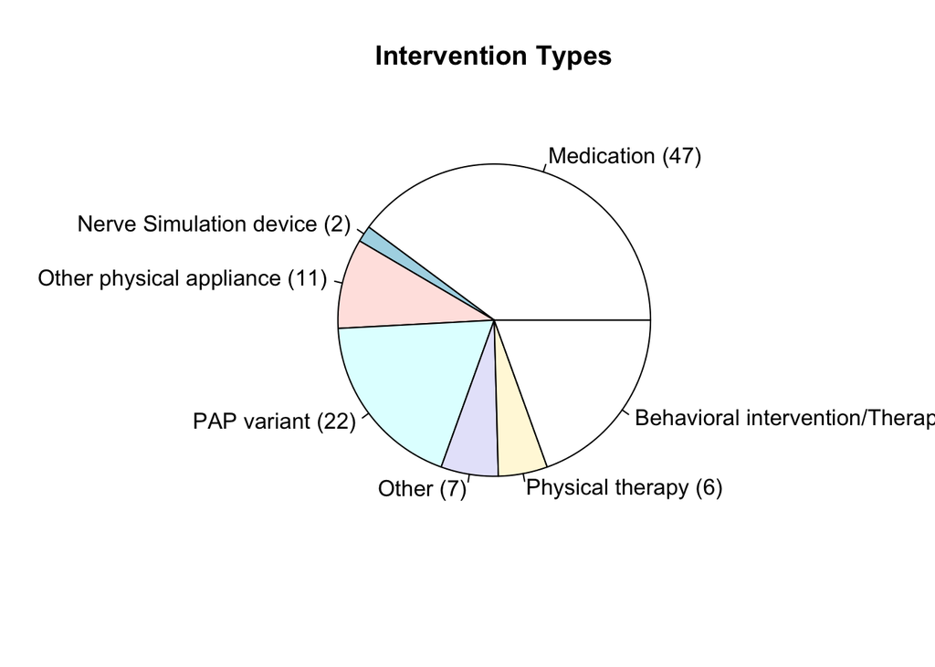

```r
intervention_frequencies <- c(
  "Medication" = 47,
  "Nerve Simulation device" = 2,
  "Other physical appliance" = 11,
  "PAP variant" = 22,
  "Other" = 7,
  "Physical therapy" = 6,
  "Behavioral intervention/Therapy" = 23
)
pie(intervention_frequencies, labels = paste(names(intervention_frequencies), " (", intervention_frequencies, ")", sep = ""), main = "Intervention Types")
```

```r
code_to_label2 <- c("1" = "Academic Organizations",
                   "2" = "Industry",
                   "3" = "VA",
                   "4" = "Charitable Organization")
osaclintrial$Sponsor_Type <- factor(osaclintrial$Sponsor_Type, levels = names(code_to_label2), labels = code_to_label2)
intervention_frequencies <- table(osaclintrial$Sponsor_Type)
print(intervention_frequencies)
```

```
 Academic Organizations                Industry                      VA
                     83                      27                       8
Charitable Organization
                      1
```

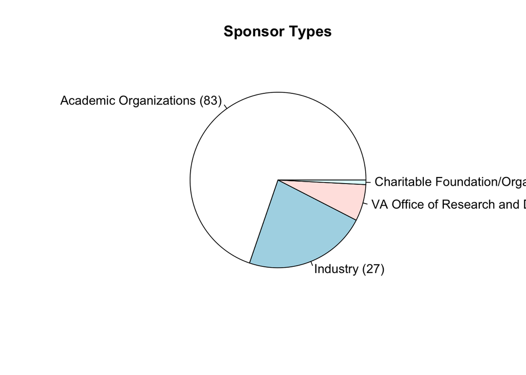

```r
sponsor_type_frequencies <- c(
  "Academic Organizations" = 83,
  "Industry" = 27,
  "VA Office of Research and Development" = 8,
  "Charitable Foundation/Organization" = 1
)
pie(sponsor_type_frequencies, labels = paste(names(sponsor_type_frequencies), " (", sponsor_type_frequencies, ")", sep = ""), main = "Sponsor Types")
```

```r
percentage_by_region <- sapply(c("NE", "MW", "S", "W"), function(region) {
  prop <- prop.table(table(osaclintrial[[region]]))
  percent_1 <- prop[2] * 100
  percent_0 <- prop[1] * 100
  data.frame(Region = region, `% of 1` = percent_1, `% of 0` = percent_0)
})
result_table <- do.call(rbind, percentage_by_region)
print(result_table)
```

```
      [,1]
 [1,] "NE"
 [2,] "41.1764705882353"
 [3,] "58.8235294117647"
 [4,] "MW"
 [5,] "30.2521008403361"
 [6,] "69.7478991596639"
 [7,] "S"
 [8,] "33.6134453781513"
 [9,] "66.3865546218487"
[10,] "W"
[11,] "40.3361344537815"
[12,] "59.6638655462185"
```

[figure not shown]

```r
if (!require(ggplot2)) {
  install.packages("ggplot2")
  library(ggplot2)
}
region_data <- data.frame(
  Region = c("Northeast", "Midwest", "South", "West"),
  Percentage = c(58.8, 69.7, 66.4, 59.7)
)
ggplot(region_data, aes(x = Region, y = Percentage)) +
  geom_bar(stat = "identity", fill = "skyblue") +
  labs(title = "Percentage of Clinical Trials by US Census Region", y = "Percentage") +
  theme_minimal()
```

# Conclusions: